# HW3 Separating Spam from Ham

Anna Prades

5 juliol de 2015

Nearly every email user has at some point encountered a “spam” email, which is an unsolicited message often advertising a product, containing links to malware, or attempting to scam the recipient. Roughly 80-90% of more than 100 billion emails sent each day are spam emails, most being sent from botnets of malware-infected computers. The remainder of emails are called “ham” emails.

As a result of the huge number of spam emails being sent across the Internet each day, most email providers offer a spam filter that automatically flags likely spam messages and separates them from the ham. Though these filters use a number of techniques (e.g. looking up the sender in a so-called “Blackhole List” that contains IP addresses of likely spammers), most rely heavily on the analysis of the contents of an email via text analytics.

In this homework problem, we will build and evaluate a spam filter using a publicly available dataset first described in the 2006 conference paper “Spam Filtering with Naive Bayes – Which Naive Bayes?” by V. Metsis, I. Androutsopoulos, and G. Paliouras. The “ham” messages in this dataset come from the inbox of former Enron Managing Director for Research Vincent Kaminski, one of the inboxes in the Enron Corpus. One source of spam messages in this dataset is the SpamAssassin corpus, which contains hand-labeled spam messages contributed by Internet users. The remaining spam was collected by Project Honey Pot, a project that collects spam messages and identifies spammers by publishing email address that humans would know not to contact but that bots might target with spam. The full dataset we will use was constructed as roughly a 75/25 mix of the ham and spam messages.

The dataset contains just two fields:

- text: The text of the email.
- spam: A binary variable indicating if the email was spam.

Begin by loading the dataset emails.csv into a data frame called emails. Remember to pass the stringsAsFactors=FALSE option when loading the data.

```r
emails <- read.csv("emails.csv", stringsAsFactors = FALSE)
#How many emails are in the dataset?
dim(emails)
```

```
## [1] 5728    2
```

```r
str(emails)
```

```
## 'data.frame':    5728 obs. of  2 variables:
##  $ text: chr  "Subject: naturally irresistible your corporate identity  lt is really hard to recollect a company : the  market is full of suqg"| __truncated__ "Subject: the stock trading gunslinger  fanny is merrill but muzo not colza attainder and penultimate like esmark perspicuous ra"| __trunc…
##  $ spam: int  1 1 1 1 1 1 1 1 1 1 ...
```

```r
#How many of the emails are spam?
table(emails$spam)
```

```
##
##    0    1
## 4360 1368
```

```r
#Which word appears at the beginning of every email in the dataset?
emails$text[1]
```

```
## [1] "Subject: naturally irresistible your corporate identity  lt is really hard to recollect a company : the  market is full of suqgestions and the information isoverwhelminq ; but a good  catchy logo , stylish statlonery and outstanding website  will make the task much easier .  we do not promis…
```

```r
emails$text[10]
```

```
## [1] "Subject: save your money buy getting this thing here  you have not tried cialls yet ?  than you cannot even imagine what it is like to be a real man in bed !  the thing is that a great errrectlon is provided for you exactiy when you want .  cialis has a lot of advantages over viagra  - the e…
```

How many characters are in the longest email in the dataset (where longest is measured in terms of the maximum number of characters)?

```r
summary(nchar(emails$text))
```

```
##    Min. 1st Qu.  Median    Mean 3rd Qu.    Max.
##    13.0   508.8   979.0  1557.0  1894.0 43950.0
```

```r
max(nchar(emails$text))
```

```
## [1] 43952
```

```r
#Which row contains the shortest email in the dataset?
which.min(nchar(emails$text))
```

```
## [1] 1992
```

```r
#Or:
min(nchar(emails$text))
```

```
## [1] 13
```

```r
which(nchar(emails$text) == 13)
```

```
## [1] 1992
```

# Preparing the corpus

```r
#1) Build a new corpus variable called corpus.
        library(tm)
        corpus <- Corpus(VectorSource(emails$text))
# 2) Using tm_map, convert the text to lowercase.
        corpus <- tm_map(corpus, tolower)
        corpus <- tm_map(corpus, PlainTextDocument)
#3) Using tm_map, remove all punctuation from the corpus.
        corpus <- tm_map(corpus, removePunctuation)
# 4) Using tm_map, remove all English stopwords from the corpus
        corpus <- tm_map(corpus, removeWords, stopwords("english"))
# 5) Using tm_map, stem the words in the corpus.
        corpus <- tm_map(corpus, stemDocument)
        strwrap(corpus[[1]])
```

```
##  [1] "subject natur irresist corpor ident lt realli hard recollect"
##  [2] "compani market full suqgest inform isoverwhelminq good catchi logo"
##  [3] "stylish statloneri outstand websit will make task much easier"
##  [4] "promis havinq order iogo compani will automaticaili becom world"
##  [5] "ieader isguit ciear without good product effect busi organ practic"
##  [6] "aim will hotat nowaday market promis market effort will becom much"
##  [7] "effect list clear benefit creativ hand made origin logo special"
##  [8] "done reflect distinct compani imag conveni logo stationeri provid"
##  [9] "format easi use content manag system letsyou chang websit content"
## [10] "even structur prompt will see logo draft within three busi day"
## [11] "afford market break shouldn t make gap budget 100 satisfact"
## [12] "guarante provid unlimit amount chang extra fee surethat will love"
## [13] "result collabor look portfolio interest"
```

```r
#6) Build a document term matrix from the corpus, called dtm.
        dtm <- DocumentTermMatrix(corpus)
#How many terms are in dtm?
        dim(dtm) #1st dimension is the nº of e-mails, 2nd nº of terms
```

```
## [1]  5728 28687
```

```r
        str(dtm)
```

```
## List of 6
##  $ i       : int [1:481719] 1 1 1 1 1 1 1 1 1 1 ...
##  $ j       : int [1:481719] 333 3880 3983 4314 5020 5453 5551 6151 6347 6445 ...
##  $ v       : num [1:481719] 1 1 1 1 1 2 1 1 1 2 ...
##  $ nrow    : int 5728
##  $ ncol    : int 28687
##  $ dimnames:List of 2
##   ..$ Docs : chr [1:5728] "character(0)" "character(0)" "character(0)" "character(0)" ...
##   ..$ Terms: chr [1:28687] "000" "0000" "000000" "00000000" ...
##  - attr(*, "class")= chr [1:2] "DocumentTermMatrix" "simple_triplet_matrix"
##  - attr(*, "weighting")= chr [1:2] "term frequency" "tf"
```

## Remove spare terms

To obtain a more reasonable number of terms, limit dtm to contain terms appearing in at least 5% of documents, and store this result as spdtm (don’t overwrite dtm, because we will use it in a later step of this homework). How many terms are in spdtm?

```r
        spdtm <- removeSparseTerms(dtm, 0.95)
        dim(spdtm)
```

```
## [1] 5728  330
```

## Create a Data frame

Build a data frame called emailsSparse from spdtm, and use the make.names function to make the variable names of emailsSparse valid.

```r
emailsSparse <- as.data.frame(as.matrix(spdtm))
```

colSums() is an R function that returns the sum of values for each variable in our data frame. Our data frame contains the number of times each word stem (columns) appeared in each email (rows). Therefore, colSums(emailsSparse) returns the number of times a word stem appeared across all the emails in the dataset. **What is the word stem that shows up most frequently across all the emails in the dataset?** Hint: think about how you can use sort() or which.max() to pick out the maximum frequency.

```r
        which.max(colSums(emailsSparse))
```

```
## enron
##    92
```

Or, you could have typed: sort(colSums(emailsSparse))

## Add the output variable

Add a variable called “spam” to emailsSparse containing the email spam labels. You can do this by copying over the “spam” variable from the original data frame (remember how we did this in the Twitter lecture).

```r
        emailsSparse$spam <- emails$spam
```

**How many word stems appear at least 5000 times *in the ham emails* in the dataset?** Hint: in this and the next question, remember not to count the dependent variable we just added.

```r
        hamSparse <- subset(emailsSparse, spam == F)                                       #Or: hamSparse <- emailsSparse[emailsSparse$spam == 0, ]
        nstemHam <- colSums(hamSparse)
        sort(nstemHam)
```

```
##       spam       life      remov      money      onlin    without
##          0         80        103        114        173        191
##     websit      click    special       wish      repli        buy
##        194        217        226        229        239        243
##        net       link     immedi       done       mean     design
##        243        247        249        254        259        261
##        lot     effect       info     either       read      write
##        268        270        273        279        279        286
##       line      begin      sorri    success     involv      creat
##        289        291        293        293        294        299
##    softwar     better     vkamin        say       keep      bring
##        299        301        301        305        306        311
##     believ       full    increas     realli    mention    thought
##        313        317        320        324        325        325
##       idea     invest      secur     specif      sever     experi
##        327        327        337        338        340        346
##      thing      allow      check        due       type      happi
##        347        348        351        351        352        354
##     return     expect      short     effort       open   internet
##        355        356        357        358        360        361
##     sincer     public     recent      anoth    alreadi       home
##        361        364        368        369        372        375
##       made    respond      given        etc        put     within
##        380        382        383        385        385        386
##      place      right    version      hello       sure       area
##        388        390        390        395        396        397
##        run     arrang    account       join       hour      locat
##        398        399        401        403        404        406
##     togeth      engin     import        per     corpor       high
##        406        411        411        412        414        416
##     result       hear      final       deal     applic       even
##        418        420        422        423        428        429
##        web     custom       soon       long       sinc      futur
##        430        433        435        436        439        440
##     member        000      event        don       part       feel
##        446        447        447        450        450        453
##    tuesday  wednesday      still       unit       site        853
##        454        456        457        457        458        461
##    continu understand    resourc     robert    analysi       form
##        464        464        466        466        468        468
```

[output cut: 57 more lines]

```
##       1577       1604       1607       1620       1643       1687
##    develop        get        new        use        let     regard
##       1691       1768       1777       1784       1856       1859
##     inform       need      power        may       like       risk
##       1883       1890       1972       1976       1980       2097
##     energi     market      model      price       work      manag
##       2124       2150       2170       2191       2293       2334
##       know      group       meet       time   research    forward
##       2345       2474       2544       2552       2752       2952
##       2001        can      thank        com      pleas   kaminski
##       3060       3426       3558       4444       4494       4801
##       2000        hou       will       vinc    subject        ect
##       4935       5569       6802       8531       8625      11417
##      enron
##      13388
```

```r
#How many word stems appear at least 1000 times in the spam emails in the dataset?
        spamSparse <- subset(emailsSparse, spam == 1)
        nstemSpam <- colSums(spamSparse)
        sort(nstemSpam) #Remember not to count spam!!!
```

```
##        713   crenshaw      enron     gibner   kaminski    stinson
##          0          0          0          0          0          0
##     vkamin        853       vinc        doc      kevin    shirley
##          0          1          1          2          2          2
##      deriv      april    houston      resum        edu     friday
##          3          5          5          5          7          7
##        hou  wednesday        ect     arrang  interview     attend
##          8          8         10         11         13         15
##     london     robert    student    schedul   thursday     monday
##         15         16         16         17         17         19
##       john    tuesday     attach    suggest    appreci       mark
##         20         20         21         21         23         25
##      begin    comment    analysi       2001      model       hope
##         26         26         27         29         29         30
##    mention       2000     togeth     confer      invit    univers
##         30         32         32         33         33         34
##     financ       talk     either        run       morn      shall
##         35         38         39         39         40         40
##      happi    thought     depart    confirm    respond     school
##         42         42         46         47         48         48
##       corp        etc       hear      howev      sorri       idea
##         49         49         49         49         50         51
##     energi    discuss       open     option       soon understand
##         55         56         56         56         57         57
##      cours     experi     associ      point      bring   director
##         59         59         62         62         63         65
##   particip      anoth       join      still      final   research
##         65         66         66         66         68         68
##       case        set     specif      given       juli    problem
##         69         69         69         70         71         73
##        put    alreadi        ask        abl       deal        fax
##         73         74         74         75         75         75
##       book       team       issu      locat       meet      updat
##         76         76         79         79         79         79
##        lot     sincer     better      short       sinc       done
##         80         80         82         82         82         83
##   question     recent    possibl   contract        end       move
##         83         83         84         85         85         86
##       data      might    continu       note       feel    resourc
##         87         87         88         88         90         90
```

[output cut: 57 more lines]

```
##        426        428        435        438        440        445
##       site    address        may       list      price        new
##        455        461        489        503        503        504
##     websit     report      secur       just      offer     invest
##        506        507        520        524        528        540
##      order        use      click        000        now        one
##        541        546        552        560        575        592
##       time       http     market       make       free      pleas
##        593        600        600        603        606        619
##      money        get     receiv     inform        can      email
##        662        694        727        818        831        865
##       busi       mail        com    compani       spam       will
##        897        917        999       1065       1368       1450
##    subject
##       1577
```

Since the lists of most common words are significantly different between the spam and ham email -> The frequencies of these most common words are likely to help differentiate between spam and ham.

Several of the most common word stems from the ham documents, such as “enron”, “hou” (short for Houston), “vinc” (the word stem of “Vince”) and “kaminski”, are likely specific to Vincent Kaminski’s inbox. This implies that the models we build are personalized, and would need to be further tested before being used as a spam filter for another person.

# Building machine learning models

```r
#convert the dependent variable to a factor
        emailsSparse$spam = as.factor(emailsSparse$spam)
        # adapt the colnames -> otherwise the RandomForest will give you an error because one column begins with a number
        colnames(emailsSparse) <- make.names(colnames(emailsSparse))
        set.seed(123)
        library(caTools)
        spl <- sample.split(emailsSparse$spam, SplitRatio = 0.7)
        train <- subset(emailsSparse, spl == T)
        test <- subset(emailsSparse, spl == F)

#Construct a logistic regression model
        spamLog <- glm(spam ~ ., data=train, family = "binomial")
        summary(spamLog) #none of the variables is significative
```

```
##
## Call:
## glm(formula = spam ~ ., family = "binomial", data = train)
##
## Deviance Residuals:
##    Min      1Q  Median      3Q     Max
## -1.011   0.000   0.000   0.000   1.354
##
## Coefficients:
##               Estimate Std. Error z value Pr(>|z|)
## (Intercept) -3.082e+01  1.055e+04  -0.003    0.998
## X000         1.474e+01  1.058e+04   0.001    0.999
## X2000       -3.631e+01  1.556e+04  -0.002    0.998
## X2001       -3.215e+01  1.318e+04  -0.002    0.998
## X713        -2.427e+01  2.914e+04  -0.001    0.999
## X853        -1.212e+00  5.942e+04   0.000    1.000
## abl         -2.049e+00  2.088e+04   0.000    1.000
## access      -1.480e+01  1.335e+04  -0.001    0.999
## account      2.488e+01  8.165e+03   0.003    0.998
## addit        1.463e+00  2.703e+04   0.000    1.000
## address     -4.613e+00  1.113e+04   0.000    1.000
## allow        1.899e+01  6.436e+03   0.003    0.998
## alreadi     -2.407e+01  3.319e+04  -0.001    0.999
## also         2.990e+01  1.378e+04   0.002    0.998
## analysi     -2.405e+01  3.860e+04  -0.001    1.000
## anoth       -8.744e+00  2.032e+04   0.000    1.000
## applic      -2.649e+00  1.674e+04   0.000    1.000
## appreci     -2.145e+01  2.762e+04  -0.001    0.999
## approv      -1.302e+00  1.589e+04   0.000    1.000
## april       -2.620e+01  2.208e+04  -0.001    0.999
## area         2.041e+01  2.266e+04   0.001    0.999
## arrang       1.069e+01  2.135e+04   0.001    1.000
## ask         -7.746e+00  1.976e+04   0.000    1.000
## assist      -1.128e+01  2.490e+04   0.000    1.000
## associ       9.049e+00  1.909e+04   0.000    1.000
## attach      -1.037e+01  1.534e+04  -0.001    0.999
## attend      -3.451e+01  3.257e+04  -0.001    0.999
## avail        8.651e+00  1.709e+04   0.001    1.000
## back        -1.323e+01  2.272e+04  -0.001    1.000
## base        -1.354e+01  2.122e+04  -0.001    0.999
```

[output cut: 294 more lines]

```
## wish         1.173e+01  3.175e+04   0.000    1.000
## within       2.900e+01  2.163e+04   0.001    0.999
## without      1.942e+01  1.763e+04   0.001    0.999
## work        -1.099e+01  1.160e+04  -0.001    0.999
## write        4.406e+01  2.825e+04   0.002    0.999
## www         -7.867e+00  2.224e+04   0.000    1.000
## year        -1.010e+01  1.039e+04  -0.001    0.999
##
## (Dispersion parameter for binomial family taken to be 1)
##
##     Null deviance: 4409.49  on 4009  degrees of freedom
## Residual deviance:   13.46  on 3679  degrees of freedom
## AIC: 675.46
##
## Number of Fisher Scoring iterations: 25
```

```r
# spamCART
        library(rpart)
```

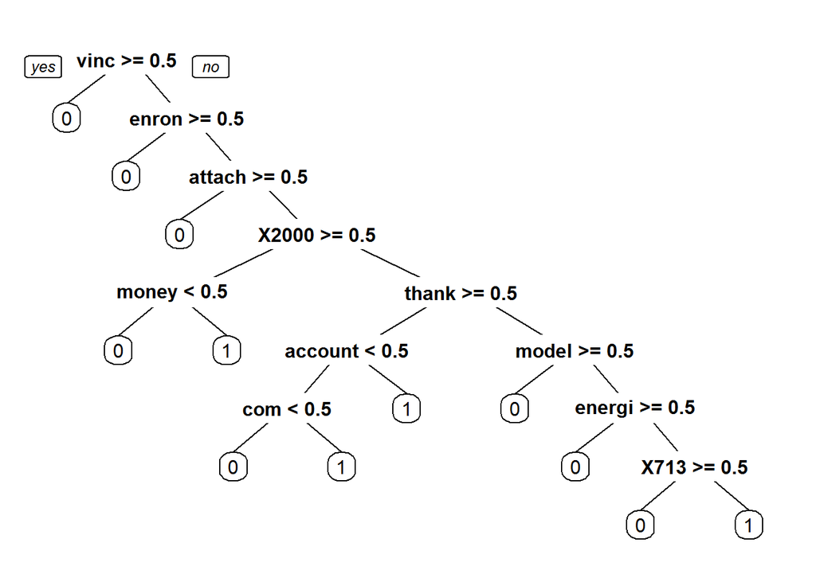

```r
        library(rpart.plot)
        spamCART <- rpart(spam ~ ., data = train, method = "class")
        prp(spamCART)
```

```r
# Build a Random Forest

        library(randomForest)
        set.seed(123)
        spamRF = randomForest(spam ~ ., data=train, method ="class")
```

You may have noticed that training the logistic regression model yielded the messages “algorithm did not converge” and “fitted probabilities numerically 0 or 1 occurred”. Both of these messages often indicate overfitting and the first indicates particularly severe overfitting, often to the point that the training set observations are fit perfectly by the model. Let’s investigate the predicted probabilities from the logistic regression model.

## Predictions

For each model, obtain the predicted spam probabilities for the training set. Be careful to **obtain probabilities instead of predicted classes**, because we will be using these values to compute training set AUC values. Recall that you can obtain probabilities for CART models by not passing any type parameter to the predict() function, and you can obtain probabilities from a random forest by adding the argument type=“prob”. **For CART and random forest, you need to select the second column of the output** of the predict() function, corresponding to the probability of a message being spam.

```r
#Predict spam probabilities for the train set
        predSpamLog <- predict(spamLog, newdata = train, type ="response")
        predSpamCART <- predict(spamCART, newdata = train)[ ,2]
        predSpamRF <- predict(spamRF, newdata = train, type = "prob" )[ ,2]
```

How many of the training set predicted probabilities from spamLog are less than 0.00001?

```r
table(predSpamLog < 0.00001) #3046
```

```
##
## FALSE  TRUE
##   964  3046
```

```r
#How many of the training set predicted probabilities from spamLog are more than 0.99999?
        table(predSpamLog > 0.99999) #954
```

```
##
## FALSE  TRUE
##  3056   954
```

```r
#How many of the training set predicted probabilities from spamLog are between 0.00001 and 0.99999?
        table(predSpamLog >= 0.00001 & predSpamLog <= 0.99999)
```

```
##
## FALSE  TRUE
##  4000    10
```

## Accuracy of the logistic model

What is the training set accuracy of spamLog, using a threshold of 0.5 for predictions?

```r
        t1 <- table(train$spam, predSpamLog > 0.5)
        t1
```

```
##
##     FALSE TRUE
##   0  3052    0
##   1     4  954
```

```r
        accuracy <- sum(diag(t1))/margin.table(t1)
        accuracy
```

```
## [1] 0.9990025
```

```r
#What is the training set AUC of spamLog?
        library(ROCR)
```

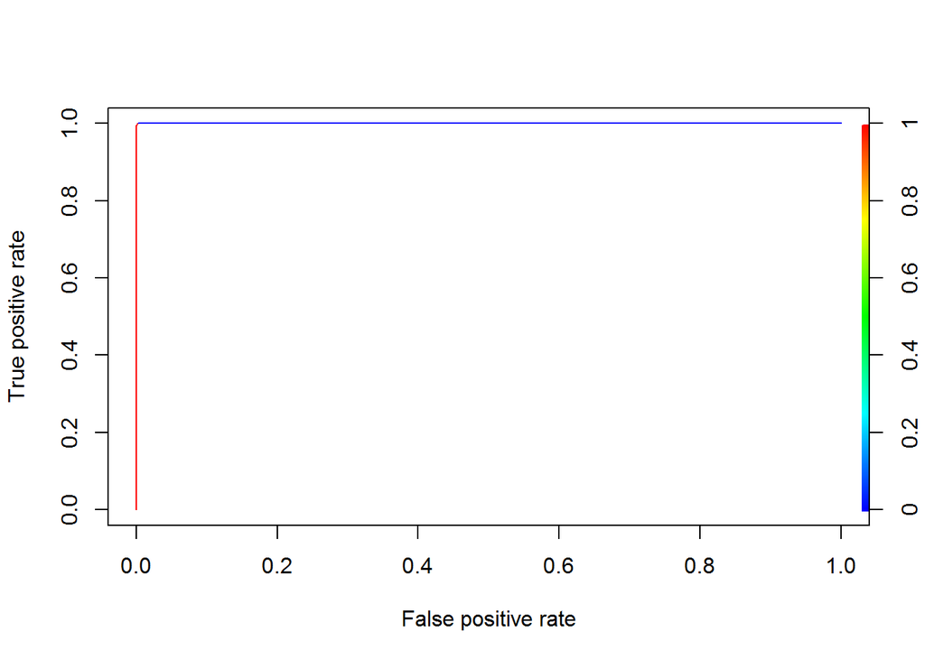

```r
        predROCR = prediction(predSpamLog, train$spam)
        perfROCR = performance(predROCR, "tpr", "fpr")
        plot(perfROCR, colorize=TRUE)
```

```r
        #Compute AUC
        performance(predROCR, "auc")@y.values
```

```
## [[1]]
## [1] 0.9999959
```

```r
        # Or:
        as.numeric(performance(predROCR, "auc")@y.values)
```

```
## [1] 0.9999959
```

MIT Solution: predictionTrainLog = prediction(predTrainLog, train$spam) as.numeric(performance(predictionTrainLog, “auc”)@y.values)

## Accuracy of the CART model

```r
        t1 <- table(train$spam, predSpamCART > 0.5)
        t1
```

```
##
##     FALSE TRUE
##   0  2885  167
##   1    64  894
```

```r
        accuracy <- sum(diag(t1))/margin.table(t1)
        accuracy
```

```
## [1] 0.942394
```

What is the **training set AUC** of spamCART? Remember that you have to pass the prediction function predicted probabilities, so don’t include the type argument when making predictions for your CART model.

```r
        library(ROCR)
        predictionTrainCART = prediction(predSpamCART, train$spam)
        as.numeric(performance(predictionTrainCART, "auc")@y.values) # 0.9696044
```

```
## [1] 0.9696044
```

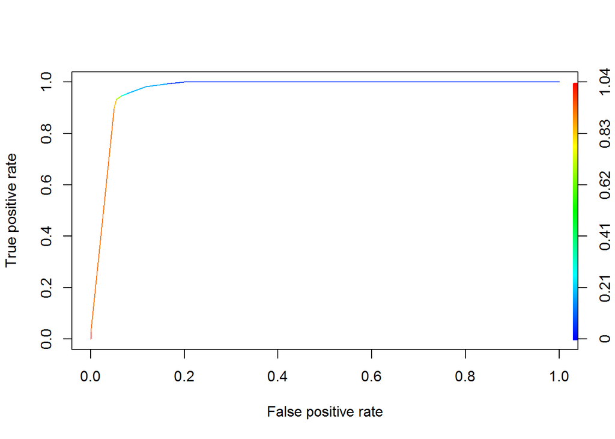

```r
        #Graph
        perfROCR = performance(predictionTrainCART, "tpr", "fpr")
        plot(perfROCR, colorize=TRUE)
```

```r
        t1 <- table(train$spam, predSpamRF > 0.5)
        t1
```

```
##
##     FALSE TRUE
##   0  3046    6
##   1     0  958
```

```r
        accuracy <- sum(diag(t1))/margin.table(t1)
        accuracy
```

```
## [1] 0.9985037
```

What is the training set AUC of spamRF? (Remember to pass the argument type=“prob” to the predict function to get predicted probabilities for a random forest model. The probabilities will be the second column of the output.)

```r
        library(ROCR)
        predictionTrainRF = prediction(predSpamRF, train$spam)
        as.numeric(performance(predictionTrainRF, "auc")@y.values)
```

```
## [1] 0.9999959
```

# Evaluating on the test set

Obtain predicted probabilities for the testing set for each of the models, again ensuring that probabilities instead of classes are obtained.

```r
   #Predict spam probabilities for the test set
        predSpamLog <- predict(spamLog, newdata = test, type ="response")
        predSpamCART <- predict(spamCART, newdata = test)[ ,2]
        predSpamRF <- predict(spamRF, newdata = test, type = "prob" )[ ,2]
```

```r
#Calculate accuracy and ACU for the Logistic model
        t1 <- table(test$spam, predSpamLog > 0.5)
        t1
```

```
##
##     FALSE TRUE
##   0  1257   51
##   1    34  376
```

```r
        accuracy <- sum(diag(t1))/margin.table(t1)
        accuracy #0.9505239
```

```
## [1] 0.9505239
```

```r
        predictionTestLog = prediction(predSpamLog, test$spam)
        as.numeric(performance(predictionTestLog, "auc")@y.values) #0.9627517
```

```
## [1] 0.9627517
```

```r
#Accuracy and ACU for the CART model
        t1 <- table(test$spam, predSpamCART > 0.5)
        t1
```

```
##
##     FALSE TRUE
##   0  1228   80
##   1    24  386
```

```r
        accuracy <- sum(diag(t1))/margin.table(t1)
        accuracy #
```

```
## [1] 0.9394645
```

```r
        predictionTestCART = prediction(predSpamCART, test$spam)
        as.numeric(performance(predictionTestCART, "auc")@y.values)
```

```
## [1] 0.963176
```

```r
#Accuracy and AUC for the RF model
        t1 <- table(test$spam, predSpamRF > 0.5)
        t1
```

```
##
##     FALSE TRUE
##   0  1290   18
##   1    26  384
```

```r
        accuracy <- sum(diag(t1))/margin.table(t1)
        accuracy #
```

```
## [1] 0.9743888
```

```r
        predictionTestRF = prediction(predSpamRF, test$spam)
        as.numeric(performance(predictionTestRF, "auc")@y.values)
```

```
## [1] 0.9975628
```

# Problem 5.1 - Assigning weights to different types of errors

Thus far, we have used a threshold of 0.5 as the cutoff for predicting that an email message is spam, and we have used accuracy as one of our measures of model quality. As we have previously learned, these are good choices when we have no preference for different types of errors (false positives vs. false negatives), but other choices might be better if we assign a higher cost to one type of error.

Consider the case of an email provider using the spam filter we have developed. The email provider moves all of the emails flagged as spam to a separate “Junk Email” folder, meaning those emails are not displayed in the main inbox. The emails not flagged as spam by the algorithm are displayed in the inbox. Many of this provider’s email users never check the spam folder, so they will never see emails delivered there.

In this scenario, what is the cost associated with the model making a false negative error? -> A spam email will be displayed in the main inbox, a nuisance for the email user.

What is the cost associated with the model making a false positive error? -> A ham email will be sent to the Junk Email folder, potentially resulting in the email user never seeing that message

Which sort of mistake is more costly? -> false positive

## Integrating word count information

While we have thus far mostly dealt with frequencies of specific words in our analysis, we can extract other information from text. The last two sections of this problem will deal with two other types of information we can extract.

First, we will use the number of words in the each email as an independent variable. We can use the original document term matrix called dtm for this task. The document term matrix has documents (in this case, emails) as its rows, terms (in this case word stems) as its columns, and frequencies as its values. As a result, the sum of all the elements in a row of the document term matrix is equal to the number of terms present in the document corresponding to the row. Obtain the word counts for each email with the command:

*wordCount = rowSums(as.matrix(dtm))* #It gives me an Error: cannot allocate vector of size 1.2Gb

```r
        library(slam)
```

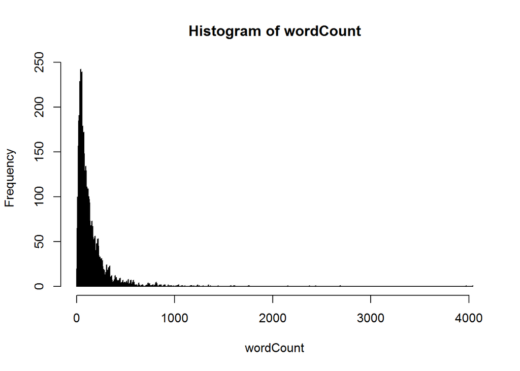

```r
        wordCount = rollup(dtm, 2, FUN=sum)$v

# Histogram of wordCount
        hist(wordCount, breaks=1000) #The data is right skewed
```

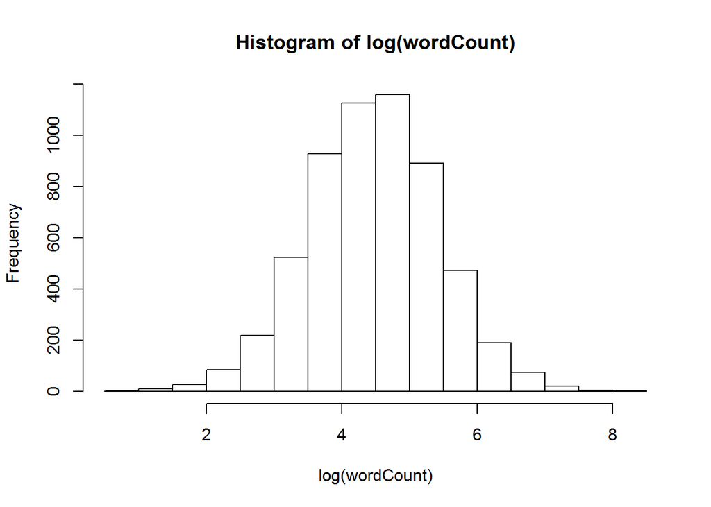

```r
# Histogram of the log of wordCount
        hist(log(wordCount))
```

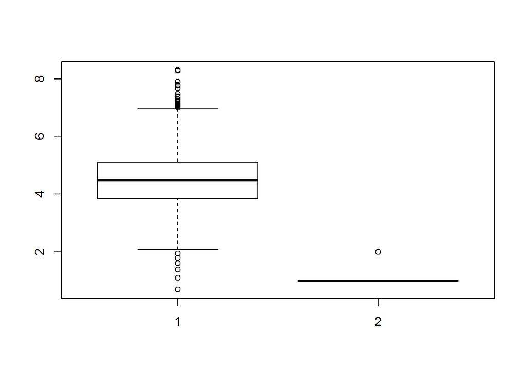

```r
emailsSparse$logWordCount <- log(wordCount)
boxplot(emailsSparse$logWordCount, emailsSparse$spam)
```

Because logWordCount differs between spam and ham messages, we hypothesize that it might be useful in predicting whether an email is spam. Take the following steps:

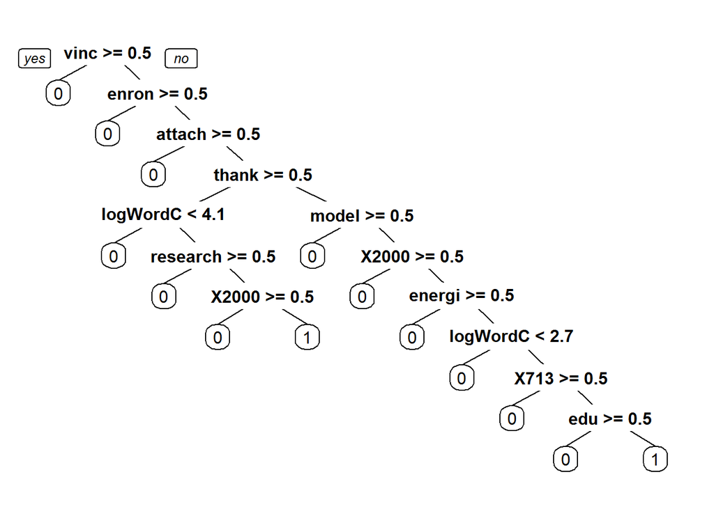

```r
#1) Use the same sample.split output you obtained earlier (do not re-run sample.split) to split emailsSparse into a training and testing set, which you should call train2 and test2.
train2 <- subset(emailsSparse, spl = T)
test2 <- subset(emailsSparse, spl = F)
#2) Use train2 to train a CART tree with the default parameters, saving the model to the variable spam2CART.
spam2CART = rpart(spam~., data=train2, method="class")
prp(spam2CART)
```

```r
#3) 3) Use train2 to train a random forest with the default parameters, saving the model to the variable spam2RF. Again, set the random seed to 123 directly before training spam2RF.

set.seed(123)
spam2RF = randomForest(spam~., data=train2)
```

## Accuracy and auc

```r
#Predictions

        predTest2CART = predict(spam2CART, newdata=test2)[,2]
        predTest2RF = predict(spam2RF, newdata=test2, type="prob")[,2]

#Accuracy and ACU for the CART model
        t1 <- table(test2$spam, predTest2CART >= 0.5)
        t1
```

```
##
##     FALSE TRUE
##   0  4173  187
##   1   131 1237
```

```r
        accuracy <- sum(diag(t1))/margin.table(t1)
        accuracy #0.9444832
```

```
## [1] 0.9444832
```

```r
        library(ROCR)
        predictionTest2CART = prediction(predTest2CART, test2$spam)
        as.numeric(performance(predictionTest2CART, "auc")@y.values)
```

```
## [1] 0.9734434
```

```r
#Accuracy and AUC for the RF model
        t1 <- table(test2$spam, predTest2RF > 0.5)
        t1
```

```
##
##     FALSE TRUE
##   0  4358    2
##   1     4 1364
```

```r
        accuracy <- sum(diag(t1))/margin.table(t1)
        accuracy
```

```
## [1] 0.9989525
```

```r
        predictionTestRF2 = prediction(predTest2RF, test2$spam)
        as.numeric(performance(predictionTestRF2, "auc")@y.values)
```

```
## [1] 0.9999458
```

## Using N-Grams

Another source of information that might be extracted from text is the frequency of various n-grams. An n-gram is a sequence of n consecutive words in the document. For instance, for the document “Text analytics rocks!”, which we would preprocess to “text analyt rock”, the 1-grams are “text”, “analyt”, and “rock”, the 2-grams are “text analyt” and “analyt rock”, and the only 3-gram is “text analyt rock”. n-grams are order-specific, meaning the 2-grams “text analyt” and “analyt text” are considered two separate n-grams. We can see that so far our analysis has been extracting only 1-grams.

We do not have exercises in this class covering n-grams, but if you are interested in learning more, the “RTextTools”, “tau”, “RWeka”, and “textcat” packages in R are all good resources.